# Beginner Math Remediation

**Mathpix and Word**

Diandra Rivera[^1]

# 1 Path Towards Accessibility

The ultimate goal of this learning module is to produce [WCAG AA](https://www.wcag.com/resource/what-is-wcag/#The_Three_Levels_of_WCAG_Conformance_A_AA_and_AAA) compliant mathematical documents that don’t punish people for needing to use assistive technology. However, while you’re learning, we still have documents that need remediation. This is a quick method using tools you are likely already familiar with that vastly increases the accessibility of such documents while you learn the preferred methods in [sections 2 and 3](https://diandramrivera.github.io/xsability/) of the learning module.

Our goals are to:

1. Convert our files into Word documents using the [Mathpix website](https://mathpix.com/).
2. Replace all figures with actual Word equations.
3. Make sure the math matches the original document.
4. Save as a read-only Word document.

**Do not save as a PDF. Do not submit as a PDF. The read-only Word document is what we will submit after remediating.**

If you are reading this, chances are you need a professional Mathpix account in order to start. Contact your superior to get such an account. You do not need paid privileges to continue with this training.

For additional assistance, please see the [Quick Start Guide](https://alexamurray-jpg.github.io/a11y/beginner-stemquick-start-guide.html)

# 2 Mathpix

We use Mathpix for 2 things:

1. Converting PDF’s into Word documents
2. Copying and pasting equations into our Word document

Both of these are forms of OCR. We’re going to walk through how both of these parts work, and then use them in the sequel.

## 2.1 Mathpix

For our process, we will always use OCR on math PDFs. The Snip app on the [Mathpix website](https://mathpix.com/) is the best for our purposes, but it will not create a perfect Word document on its own.

**Almost all of the added difficulty in STEM remediation is fixing the errors that Mathpix creates.**[^2]

Which, conceptually, isn’t so different from having to fix the OCR and “auto-tag” errors Acrobat creates during PDF remediation. In general, the following errors may occur:

- Footnotes and references being labeled as math
- Equations mistakenly being copied images
- The penmanship of your average STEM professor being interpreted as a colorful array of jibberish

All of these require our scrutiny.

Conversion of large PDFs requires a Mathpix license (if you are a STARS member, ask your GAA). With a license, up to 1000 pages can be converted at any time.

Once you have access to Mathpix, log in and launch the ‘Snip Webapp’.

[figure not shown]

Figure 2.1.1: Click the blue “Launch App” button to start uploading PDF’s.

This will take us to the Snip app, where we can upload, edit, and export files.

[figure not shown]

Figure 2.1.2: First, click on “Files”. Then, click on the “+” symbol and select “upload PDF file”.

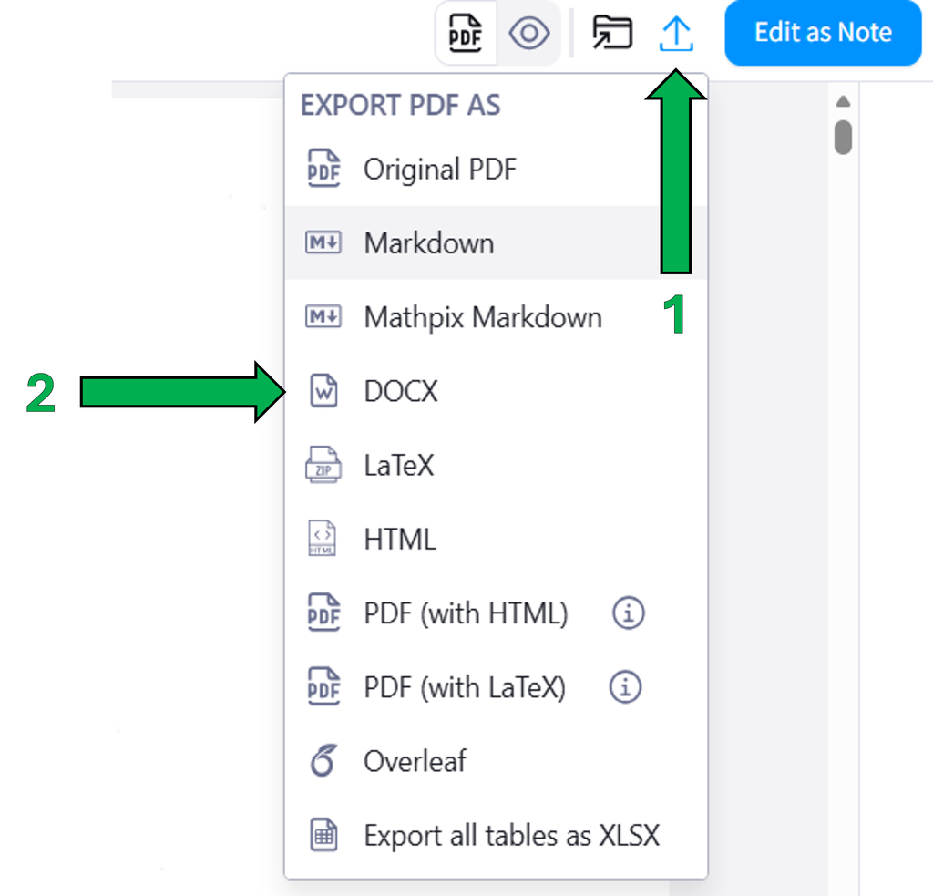

Figure 2.1.3: First, click on the “up arrow” to select export options. Then, click on “DOCX” to save a Word document.

Once your file is uploaded, export it to Word by clicking the up arrow (export) in the top right, and selecting “DOCX”

Save your file to your designated working folder (discussed below). Now you can open the Word file and start remediating it.

## 2.2 Snips Tool

We can copy and paste screenshots of math into the Snips tool. It will give us properly formatted[^3] Word equations that we can copy and paste into our Word documents. This makes remediation *a lot easier*.

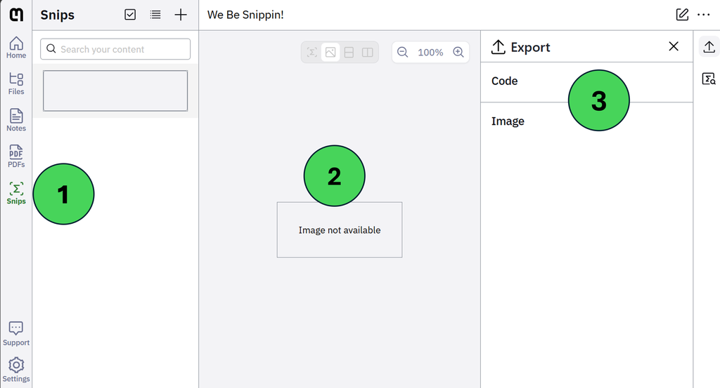

Figure 2.2.1: There are three steps to using the Snips tool, described below.

Let’s find a good example to test this out. Consider the [Caputo Fractional Derivative](https://en.wikipedia.org/wiki/Caputo_fractional_derivative):

[figure not shown]

Figure 2.2.2: The Wikipedia entry for the Caputo Fractional Derivative (see above link). I’m sure it’s very interesting, but let's take a screenshot of the equation in the green rectangle to understand how Snips works (see footnote for equation)[^4].

After we take a screenshot, click on Part 2 in fig. 2.2.1 and press `ctrl+v` to paste the image into the Snips tool.

[figure not shown]

Figure 2.2.3: Pasting our image into the Snips tool lets us generate “plain text” representations of the equation that we can copy and paste!

In the above, we see:

1. The image we pasted
2. What Mathpix is interpreting from our image (note the options for screen layout above item 1)
3. A list of formats we can export our equation to, with “MathML (MS Word) selected”

Click on 3, and you automatically copy the equation. Pasting this into a Word document yields the following:

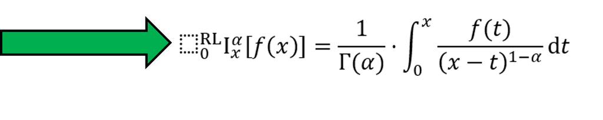

Figure 2.2.4: The equation from Mathpix is *almost* what we want.

*SO CLOSE!!!* There’s a blank box in our equation. There aren’t any blank boxes in our equation! In order to get ride of this, click on it and press `spacebar`, and we have the following:

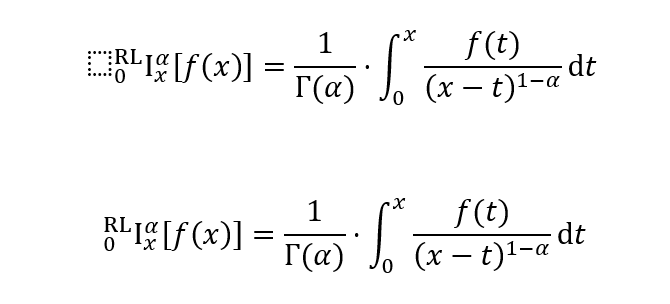

Figure 2.2.5: The [Caputo Fractional Derivative](https://en.wikipedia.org/wiki/Caputo_fractional_derivative) copied into Word properly. Above it is the erroneous equation from fig. 2.2.4 to highlight the differences.

Now that we know how Mathpix and Snips work, let’s use them!

# 3 Word Remediation

To remind ourselves what we need to do after converting a PDF to a Word document:

1. Convert any images that Mathpix made into actual Word math (in professional mode).
2. Make sure our Word math matches the source material *exactly*.
3. Save as a read-only Word document (this is what we will upload).

The above 3 are **in addition** to regular remediation tasks, such as alt-text and ensuring proper heading structures.

Let’s use page 28 of the freely available “Continuum Mechanics” by Eduardo Chaves [available in the learning module](https://diandramrivera.github.io/xsability/ChavesPg28.pdf).

The PDF:

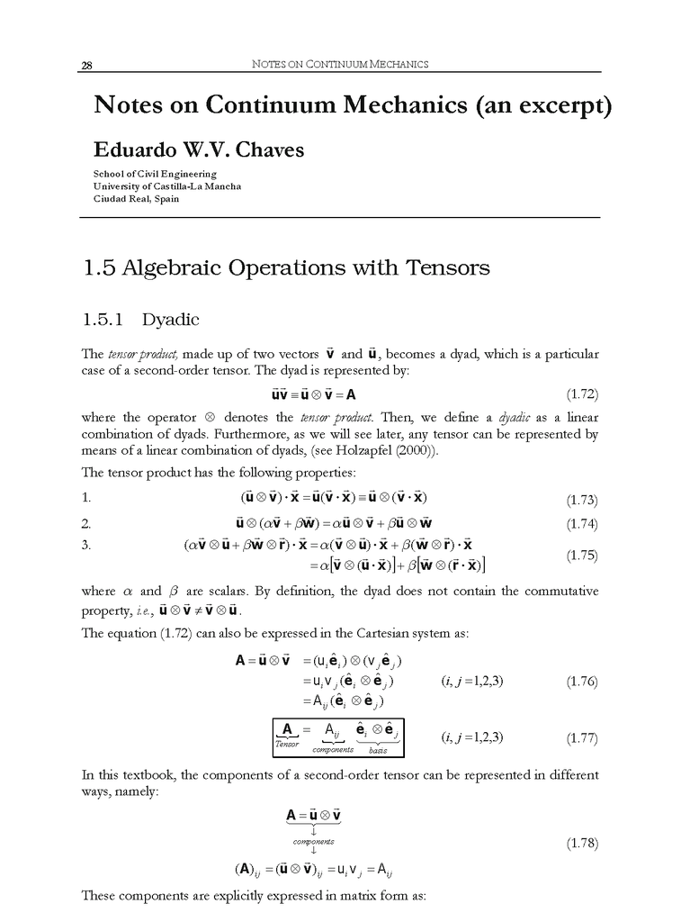

Figure 3.1: This excerpt from “Continuum Mechanics” is mathematically dense and completely unreadable by assistive technology in PDF format.

is transcribed into a Word document according to sec. 2:

[figure not shown]

Figure 3.2: The transcribed Word document of our inaccessible PDF. A green arrow is pointing towards the “review” panel.

and now we have to do the work of remediation.

## 3.1 Part 1: Fixing Mathpix Image Errors

and as with any Word document the very first thing we should do is open the Review Panel and click ‘Check Accessibility’.

[figure not shown]

Figure 3.1.1: First, click on Accessibility Checker, then look for issues in the right pane. Wait—alt text?

Alt-text is for figures. It’s quite strange that we would have such an error here, because this PDF only contained text. We scroll down to see the culprit:

[figure not shown]

Figure 3.1.2: Aha! As foretold, Mathpix converted an equation into a figure!

We ran across our first Mathpix error. This is relatively common, and usually an easy thing to fix. We notice that the notation in the figure is pretty similar to some of the notation above it. We have two options:

1. Copy and paste the entire equation using the Snips tool
2. Copy and paste the notation above it, which includes a lot of fiddling with Microsoft Word’s formatting engine

The first is the most convenient way. Copy the entire equation 1.78 in Chaves and paste it into Mathpix. **Make the equation as big as possible in the PDF before you copy it**.

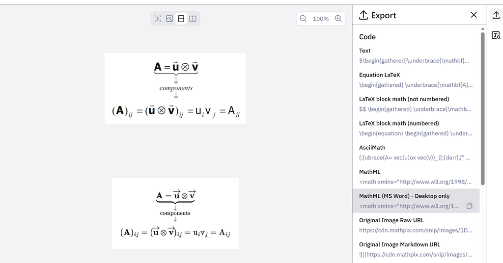

Copy the equation 1.78 into Snips as in sec. 2.2. Making the equation as big as possible improves the acccuracy of Mathpix’s proprietary OCR technology.

Now, replace everything associated with equation 1.78 with what we copied from Mathpix.

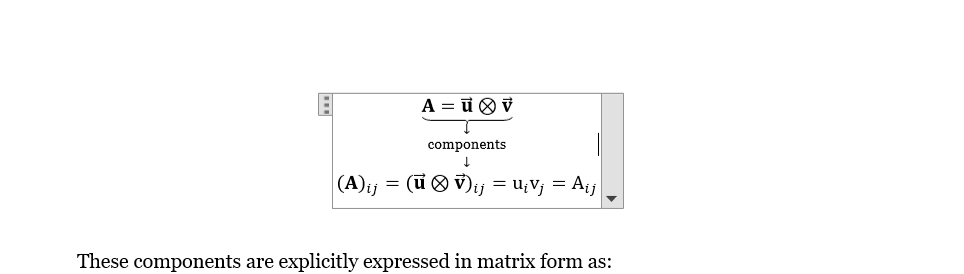

Figure 3.1.3: With a little copying and pasting, we replaced the image with the actual equation. But what about the equation number?

But wait, how do we get the equation number back? Let’s introduce ourselves to the idea of “markup” - my recommendation to you is to move to the end of the equation, type ‘#(1.78)’ then press **Enter**, like so:

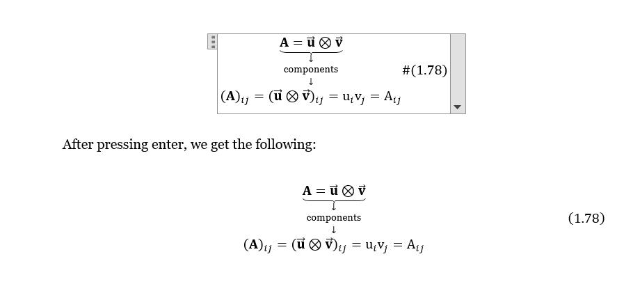

Figure 3.1.4: We just used Word markup to format an equation number—wait, what’s markup again?

We just used our very first example of markup—*annotated text*—to tell a computer how to format a document. We’ll learn more about this in the main course. For now, let’s finish making this document accessible.

## 3.2 Sanity Check

Does your result match fig. 3.1.4? If not, make sure it does. (Reach out for help if you’re stuck!)

## 3.3 Part 2: Matching Source Material

We fixed the equation. The Accessibility Checker says that we are done. **But We are not done**. We have more errors to fix. Look at the following:

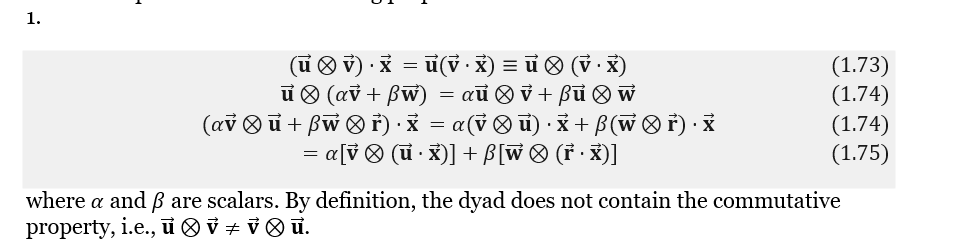

Figure 3.3.1: Ah! Mathpix made an error for Eq. 1.73-75!!!

Recall from fig. 3.1 that equations 1.73-75 should be in a list. This should be pretty easy to fix by inserting a list and copying and pasting the equations into the list. **We don’t have time for that**. Let’s use Mathpix instead.

[figure not shown]

Figure 3.3.2: Mathpix produced a list and numbering for us! Note: Snips can’t handle document formatting like lists, so we’ll have to export from Snips a Word document and copy whats inside to the file we’re remediating.

As in sec. 3, we’re going to delte *all* of the quations in question from our word document and replace them with what Mathpix produced. We should see the following:

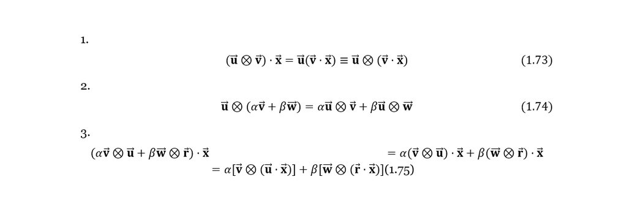

Figure 3.3.3: The equations that Mathpix gave us aren’t formatted exactly right!!!

The last equation in our list is a bit of a mess. That’s okay - we actually have the equations we need in the Word file we’re remediating. **Delete the mess**, and **copy and paste the last two lines** in fig. 3.3.1 into the list. You should see the following.

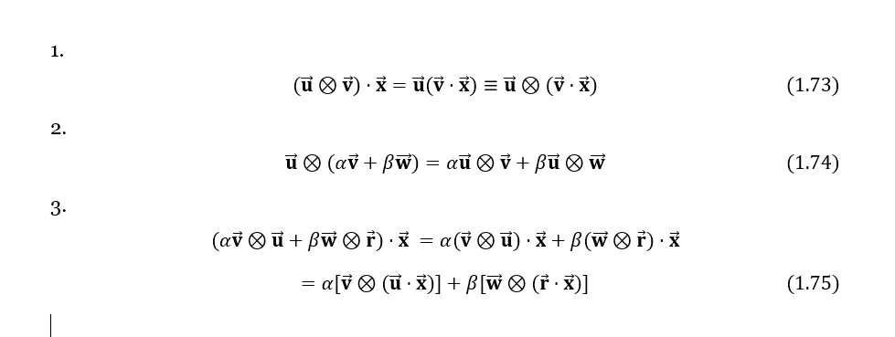

Figure 3.3.4: There’s always something we can copy and paste that will help us. Sometimes we have to use a mixture of the document Mathpix gave us and the equations that Snips produces!

This touches on a broader point: **it is your job to make sure that the equations and their formatting communicate the same information after remediation**. While the exact spacing of the equations may be slightly different due to differences between Word and other authoring tools, *every* symbol, *every* term, and *every* number **must be equivalent**.

Numbered, centered equations like this should **always** be in “Professional” mode because the rules for how a screen reader interacts with them become optimized for multiscale investigation. Mathpix does this for us, but we can double check by clicking on the right side of the equation environment, like so:

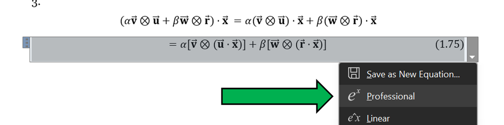

Figure 3.3.5: Professional Mode equations are a requirement for accessibility. If you edit an equation yourself, make sure to select this option from the equation environment drop down.

**There are a few other Mathpix-induced errors**. Can you find them and fix them? Hint: compare the bottom of fig. 3.2 with the source material in the PDF. *Do you think the little “hats” are where they should be in the word document Mathpix produced?* Try using the Snips tool!

After you verify the above are fixed, our Accessibility Checker says we’re done, and our eyes say we’re done. *We’re done*.

## 3.4 Part 3: Saving as Read-only

Before we upload this Word document, we need to save it as read-only. These instructions may be slightly different for the Mac version of Word than for Windows. It’s recommended you google search this if you use a Mac for remediation work.

Click on ‘Save-as’ and ‘Browse’ as you normally would, then “Tools” and ‘General Options’.

[figure not shown]

then we select ‘Read-only recommended’.

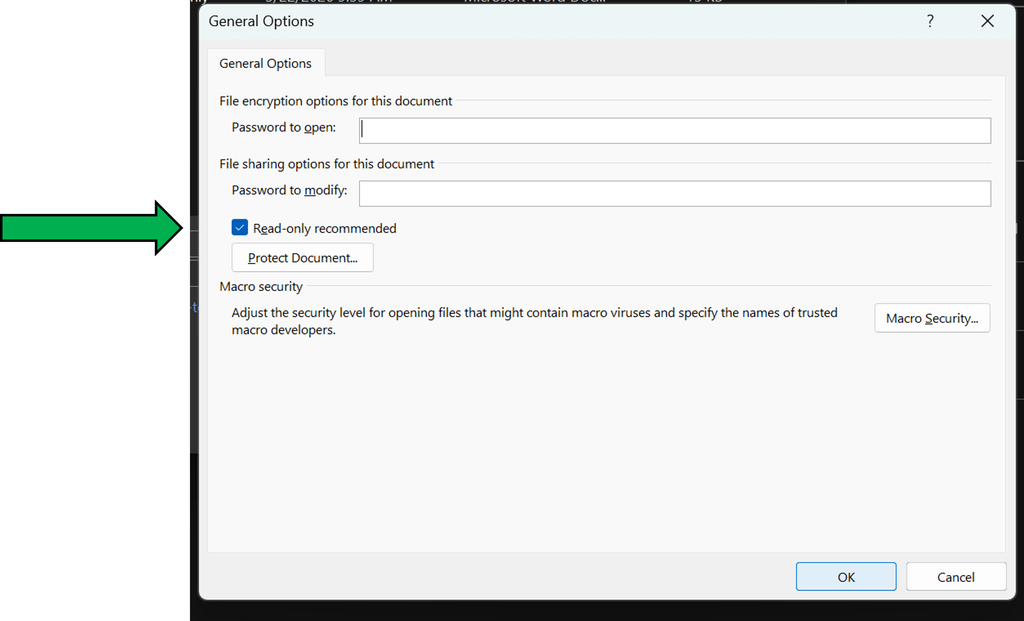

Figure 3.4.2: Selecting ‘Read-only Recommended’ forces the file to open in read-only mode, preventing unwanted document changes similarly to Adobe Acrobat.

The steps outlined in fig. 3.4.1 and fig. 3.4.2 are REQUIRED before you upload your file. As always, make sure your remediated file matches the file name of its original.

**DO NOT SAVE AS A PDF. DO NOT UPLOAD AS A PDF. OUR GOAL IS THE READ-ONLY WORD DOCUMENT. THIS IS WHAT YOU WILL UPLOAD WHEN WE UPLOAD MATHEMATICAL DOCUMENTS IF YOU HAVE NOT FINISHED THE MAIN COURSE.**

# 4 What’s Next

You should gather that remediating math is already a difficult task, but dealing with formatting in Word *sucks*. In the sequel, we will learn about tools and methods that will let us focus on the math alone *and do the formatting for us*.

Share your remediated Word document with your superior to verify your understanding and begin with the next steps of your training. At this point, you may begin remediation tasks following the above principles.

[Return to the learning module home page.](https://diandramrivera.github.io/xsability)

[^1]: Warmest thanks to Lexi Murray for the insightful instruction and feedback about Mathpix Snips, and a special acknowledgement to Esther Blankson for the incredibly helpful feedback.
[^2]: and describing figures correctly - we’ll get there.
[^3]: most of the time…
[^4]: The Caputo Fractional Derivative in fig. 2.2.2 is as follows:

    $${ }_0^{\mathrm{RL}}
    \mathrm{I}_x^\alpha[f(x)]=\frac{1}{\Gamma(\alpha)} \cdot \int_0^x
    \frac{f(t)}{(x-t)^{1-\alpha}} \mathrm{d}t$$